# Los Datos detrás del balón - Trabajo Académico MDP I

## 9.12 ANEXO 12: Biplots de las componentes principales

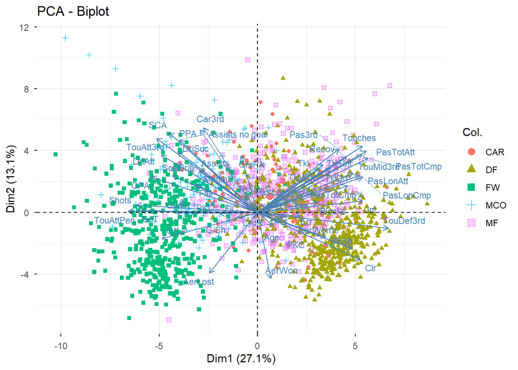

En este biplot representamos simultáneamente a los jugadores (como puntos) y a las variables originales (como flechas) en el plano formado por las dimensiones 1 y 2. Esta visualización nos permite observar cómo se distribuyen los jugadores según su posición, y qué variables influyen más en cada zona del gráfico.

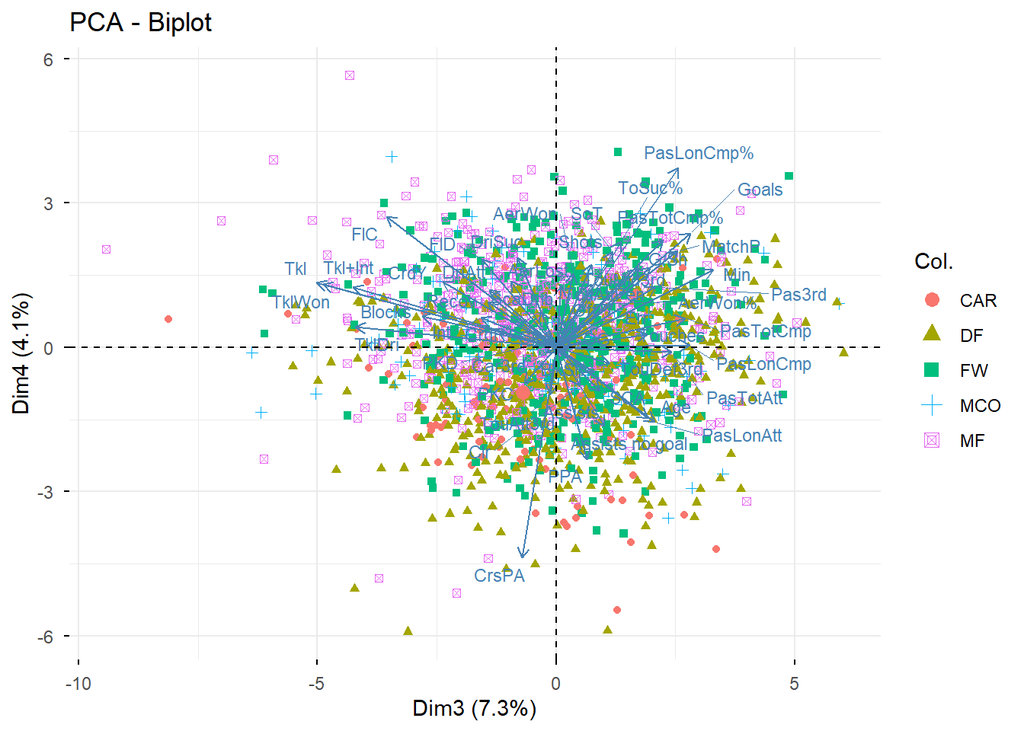

En este segundo biplot, donde se representan las dimensiones 3 y 4, no se aprecia una separación clara entre las posiciones. La mayoría de los puntos están muy concentrados en el centro del gráfico, y las flechas de las variables aparecen muy juntas entre sí.

Esto sugiere que estas dimensiones no son tan útiles para clasificar a los jugadores por su rol o estilo de juego, aunque sí podrían estar capturando otras características más complejas o difíciles de interpretar, como el valor de mercado, tal y como vimos anteriormente en los gráficos de variables.

## 9.13 ANEXO 13: Estadístico de Hopkins

```
##    Min. 1st Qu.  Median    Mean 3rd Qu.    Max.
##       1       1       1       1       1       1
```

## 9.14 ANEXO 14: Método de la Media

Estimamos a continuación el número óptimo de clusters para el método de la media.

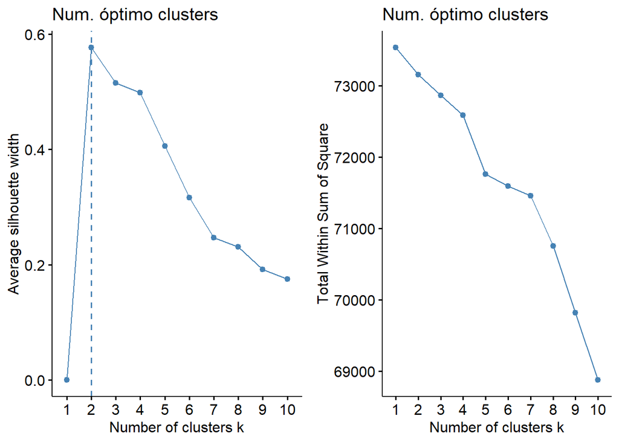

El valor máximo de la silhouette se alcanza claramente para 2 clusters, pero los valores para 3, 4 y hasta 5 clusters siguen siendo relativamente altos (por encima de 0.4), lo que indica que la estructura de agrupamiento sigue siendo razonablemente buena con más de dos grupos. La suma de cuadrados dentro de los grupos disminuye de manera casi lineal, sin un codo muy marcado, aunque la pendiente se suaviza ligeramente a partir de 5 clusters. Probamos con 5 clusters:

```
## grupos2
##    1    2    3    4    5
## 1792    1    5    1    1
```

La distribución resultante de los 5 clusters usando el método de la media (average) muestra que la gran mayoría de los jugadores (1792) han sido agrupados en un solo cluster, mientras que los otros cuatro clusters solo contienen 1 o 5 jugadores cada uno. Esto indica que el agrupamiento no es efectivo ni equilibrado: la partición no está captando subgrupos relevantes, sino que la mayoría de los datos quedan en un único grupo y los demás son prácticamente outliers. Por lo tanto lo descartamos.

## 9.15 ANEXO 15: NbClust

Otra alternativa, es utilizar la librería NbClust, que aplica varios criterios y elegir el número de clusters más votado (por más criterios diferentes). Lo aplicaremos entre 2 y 6 clusters:

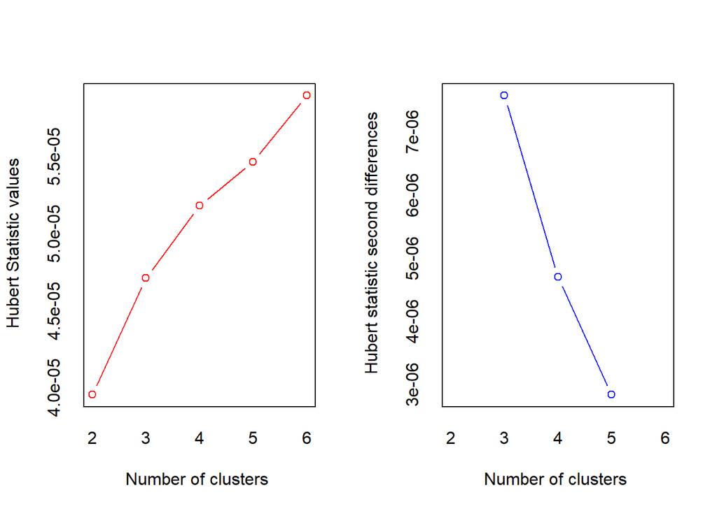

```
## *** : The Hubert index is a graphical method of determining the number of clusters.
##                 In the plot of Hubert index, we seek a significant knee that corresponds to a
##                 significant increase of the value of the measure i.e the significant peak in Hubert
##                 index second differences plot.
##
```

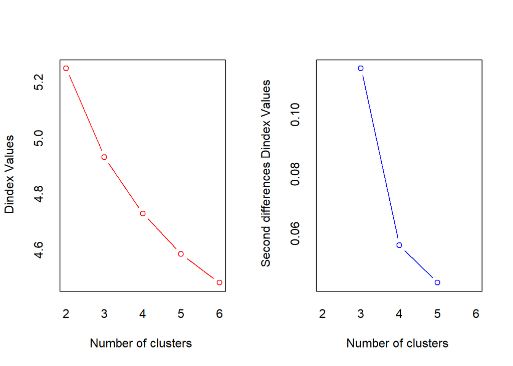

```
## *** : The D index is a graphical method of determining the number of clusters.
##                 In the plot of D index, we seek a significant knee (the significant peak in Dindex
##                 second differences plot) that corresponds to a significant increase of the value of
##                 the measure.
##
## * Among all indices:
## * 8 proposed 2 as the best number of clusters
## * 9 proposed 3 as the best number of clusters
## * 1 proposed 4 as the best number of clusters
## * 5 proposed 6 as the best number of clusters
##
##                    ***** Conclusion *****
##
## * According to the majority rule, the best number of clusters is  3
##
##
```

## 9.16 ANEXO 16: Clustering - PCA

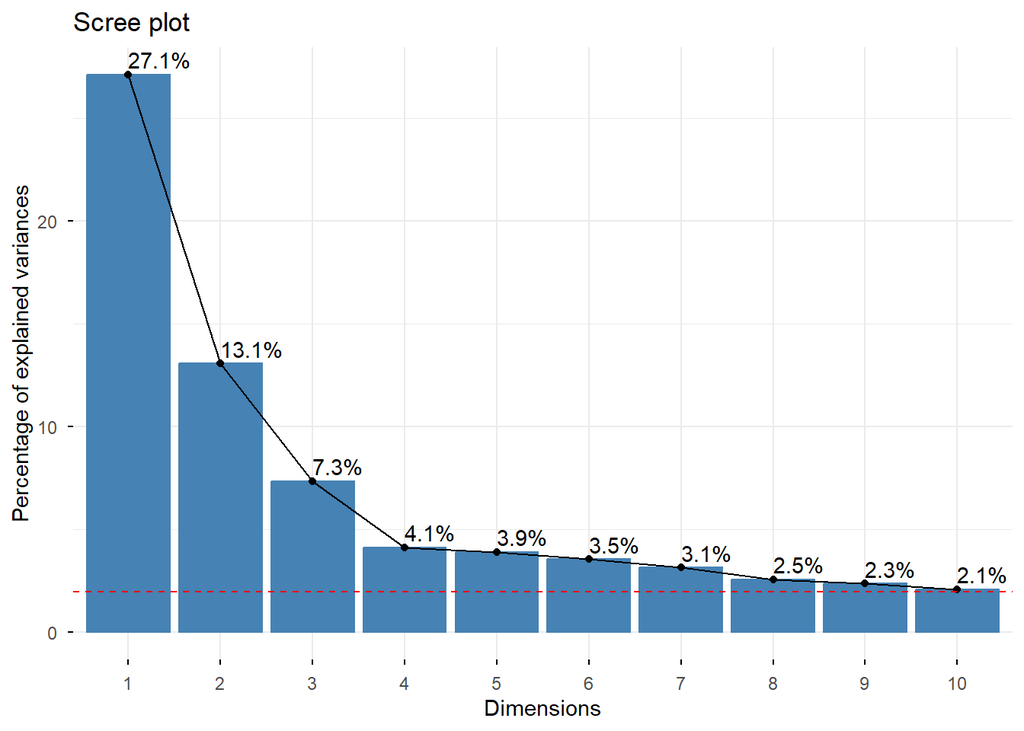

La mayor parte de la información se concentra en las primeras 3-4 componentes principales, por lo que para reducir la dimensionalidad, sería razonable quedarse con ellas. Los componentes posteriores explican poca varianza y aportan información marginal.

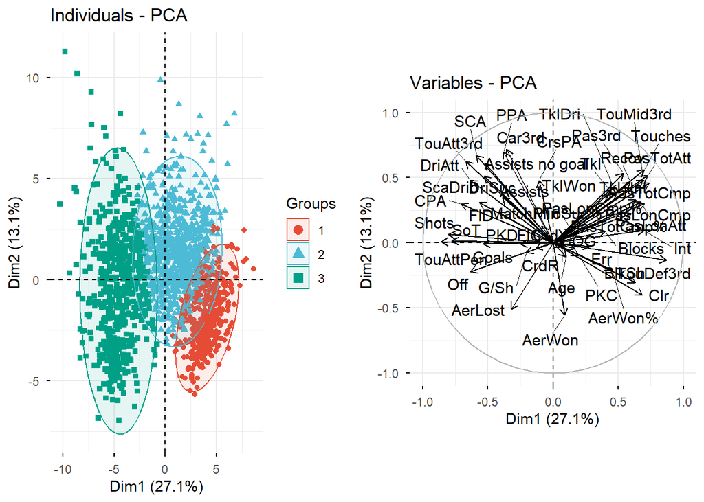

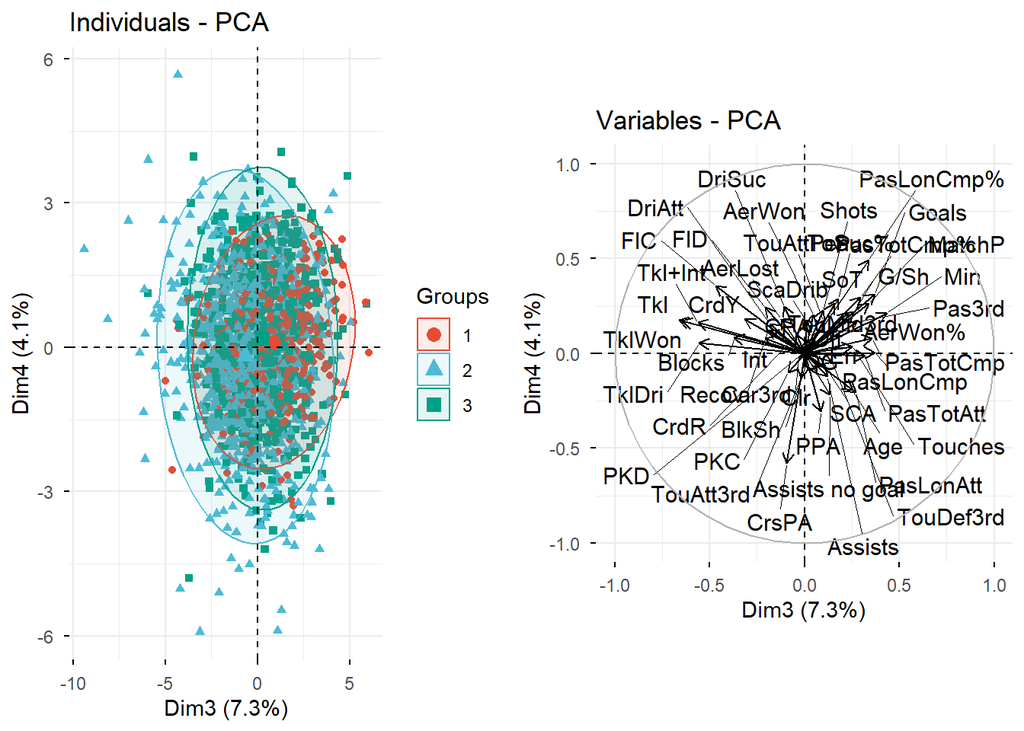

## 9.17 ANEXO 17: Interpretación del Clustering Valores Medios

|  | c1 | c2 | c3 |
| --- | --- | --- | --- |
| Age | 0.13 | -0.02 | -0.07 |
| MatchP | -0.19 | 0.03 | 0.09 |
| Min | 0.25 | 0.01 | -0.20 |
| Goals | -0.43 | -0.30 | 0.72 |
| Shots | -0.82 | -0.33 | 1.05 |
| SoT | -0.73 | -0.37 | 1.03 |
| G/Sh | -0.05 | -0.19 | 0.29 |
| PasTotCmp | 0.67 | 0.32 | -0.92 |
| PasTotAtt | 0.58 | 0.38 | -0.93 |
| PasTotCmp% | 0.73 | 0.14 | -0.72 |
| PasLonCmp | 0.81 | 0.16 | -0.81 |
| PasLonAtt | 0.74 | 0.22 | -0.83 |
| PasLonCmp% | 0.28 | -0.01 | -0.19 |
| Assists | -0.56 | 0.00 | 0.41 |
| Assists no goal | -1.01 | 0.17 | 0.50 |
| Pas3rd | 0.14 | 0.46 | -0.73 |
| PPA | -0.90 | 0.28 | 0.27 |
| CrsPA | -0.60 | 0.39 | -0.10 |
| SCA | -1.13 | 0.17 | 0.59 |
| ScaDrib | -0.58 | -0.20 | 0.69 |
| Tkl | -0.18 | 0.61 | -0.70 |
| TklWon | -0.12 | 0.55 | -0.66 |
| TklDri | -0.04 | 0.57 | -0.74 |
| Blocks | 0.30 | 0.24 | -0.55 |
| BlkSh | 1.21 | -0.14 | -0.68 |
| Int | 0.68 | 0.30 | -0.89 |
| Tkl+Int | 0.20 | 0.57 | -0.91 |
| Clr | 1.36 | -0.18 | -0.74 |
| Err | 0.46 | -0.03 | -0.30 |
| Touches | 0.53 | 0.38 | -0.91 |
| TouDef3rd | 1.42 | -0.03 | -0.98 |
| TouMid3rd | 0.37 | 0.46 | -0.89 |
| TouAtt3rd | -1.29 | 0.20 | 0.67 |
| TouAttPen | -0.79 | -0.40 | 1.12 |
| DriAtt | -0.89 | -0.05 | 0.71 |
| DriSuc | -0.77 | -0.03 | 0.59 |
| ToSuc% | 0.23 | -0.01 | -0.16 |
| Car3rd | -0.86 | 0.26 | 0.26 |
| CPA | -0.69 | -0.27 | 0.87 |
| CrdY | 0.03 | 0.09 | -0.15 |
| CrdR | 0.17 | -0.04 | -0.07 |
| FlC | -0.40 | 0.12 | 0.12 |
| FlD | -0.72 | 0.03 | 0.48 |
| Off | -0.52 | -0.37 | 0.88 |
| PKD | -0.18 | -0.17 | 0.36 |
| PKC | 0.35 | -0.03 | -0.22 |
| OG | 0.34 | -0.05 | -0.17 |
| Recov | 0.19 | 0.52 | -0.85 |
| AerWon | 0.56 | -0.35 | 0.08 |
| AerLost | -0.08 | -0.36 | 0.55 |
| AerWon% | 0.73 | -0.04 | -0.48 |

## 9.18 ANEXO 18: Análisis Discriminante

```
##
##  Bajo Medio  Alto
##  1386   335    79
```

```
##      Bajo     Medio      Alto
## 0.7696044 0.1859820 0.0444136
```

```
##               Age      MatchP        Min      Goals       Shots        SoT
## Bajo   0.06349179 -0.09794896 -0.1106568 -0.1563403 -0.09994711 -0.0997190
## Medio -0.17099228  0.30652214  0.3141325  0.3233204  0.23375864  0.2278141
## Alto  -0.28292702  0.41371037  0.6020447  1.3551806  0.75303166  0.7739716
##            `G/Sh`   PasTotCmp   PasTotAtt `PasTotCmp%`    PasLonCmp   PasLonAtt
## Bajo  -0.06015597 -0.09587057 -0.08648652  -0.08455751 -0.013022699  0.01084360
## Medio  0.16867348  0.26005543  0.23431764   0.24104656  0.007755825 -0.04970512
## Alto   0.33606990  0.57227506  0.51744417   0.45584056  0.193181433  0.02024084
##       `PasLonCmp%`     Assists `Assists no goal`     Pas3rd        PPA
## Bajo   -0.07766914 -0.09546822        -0.1122067 -0.0820470 -0.1094593
## Medio   0.21796940  0.19867151         0.2637556  0.2194400  0.2146533
## Alto    0.43311371  0.82234836         0.8398545  0.5028156  0.9978632
##              CrsPA        SCA     ScaDrib         Tkl      TklWon      TklDri
## Bajo   0.004138207 -0.1240920 -0.05189996  0.03954722  0.03647352  0.03838984
## Medio -0.020605531  0.2875989  0.08800276 -0.08092903 -0.08058080 -0.09517927
## Alto   0.014578285  0.9459613  0.53081746 -0.34638889 -0.29458562 -0.26666074
##            Blocks       BlkSh         Int  `Tkl+Int`         Clr          Err
## Bajo   0.03107020  0.05190018  0.05145750  0.0518391  0.06878819  0.002332371
## Medio -0.07448757 -0.13836914 -0.09831725 -0.1029152 -0.16964218 -0.030519336
## Alto  -0.22647158 -0.31991196 -0.47995843 -0.4673169 -0.48159366  0.087384104
##           Touches   TouDef3rd   TouMid3rd  TouAtt3rd  TouAttPen     DriAtt
## Bajo  -0.09017144  0.02877469 -0.06873241 -0.1164190 -0.1180873 -0.0610395
## Medio  0.24510934 -0.06121766  0.21030904  0.2664861  0.2714166  0.1166824
## Alto   0.53610662 -0.24226250  0.31033472  0.9014119  0.9096745  0.5690927
##            DriSuc    `ToSuc%`      Car3rd         CPA        CrdY        CrdR
## Bajo  -0.07292495 -0.02659347 -0.08621205 -0.09504546  0.04044644  0.02875191
## Medio  0.14612440  0.06073507  0.15355265  0.19854938 -0.10542767 -0.09210881
## Alto   0.65175670  0.20648684  0.85089150  0.81553408 -0.25938265 -0.11251105
##               FlC         FlD         Off          PKD         PKC           OG
## Bajo   0.04464488 -0.02489088 -0.02951905 -0.012798813  0.03262424 -0.020012862
## Medio -0.10414649  0.04138436  0.03759758  0.001745744 -0.08266207  0.080596017
## Alto  -0.33749858  0.25801530  0.35406998  0.214469122 -0.21916943  0.009289556
##              Recov      AerWon    AerLost    `AerWon%` valor_mercado
## Bajo   0.009776326  0.03210594  0.0593924 -0.009804549    -0.4174529
## Medio  0.017919376 -0.06226992 -0.1477277  0.067583106     0.8772453
## Alto  -0.244442781 -0.29558045 -0.4105491 -0.113109807     3.5602110
```

```
##                 LD1         LD2
## Age     0.068566768  0.28888628
## MatchP -0.028147459 -0.24442584
## Min     0.008806942 -0.34596735
## Goals  -0.119079084  0.47542394
## Shots   0.046812312 -0.22775442
## SoT    -0.086663569 -0.08098119
```

```
## Confusion Matrix and Statistics
##
##           Reference
## Prediction Bajo Medio Alto
##      Bajo  1109    35    0
##      Medio    0   233    3
##      Alto     0     0   61
##
## Overall Statistics
##
##                Accuracy : 0.9736
##                  95% CI : (0.964, 0.9813)
##     No Information Rate : 0.7696
##     P-Value [Acc > NIR] : < 2.2e-16
##
##                   Kappa : 0.9261
##
##  Mcnemar's Test P-Value : NA
##
## Statistics by Class:
##
##                      Class: Bajo Class: Medio Class: Alto
## Sensitivity               1.0000       0.8694     0.95312
## Specificity               0.8946       0.9974     1.00000
## Pos Pred Value            0.9694       0.9873     1.00000
## Neg Pred Value            1.0000       0.9710     0.99783
## Prevalence                0.7696       0.1860     0.04441
## Detection Rate            0.7696       0.1617     0.04233
## Detection Prevalence      0.7939       0.1638     0.04233
## Balanced Accuracy         0.9473       0.9334     0.97656
```

```
## Confusion Matrix and Statistics
##
##           Reference
## Prediction Bajo Medio Alto
##      Bajo   277    10    0
##      Medio    0    57    2
##      Alto     0     0   13
##
## Overall Statistics
##
##                Accuracy : 0.9666
##                  95% CI : (0.9423, 0.9826)
##     No Information Rate : 0.7716
##     P-Value [Acc > NIR] : < 2.2e-16
##
##                   Kappa : 0.9048
##
##  Mcnemar's Test P-Value : NA
##
## Statistics by Class:
##
##                      Class: Bajo Class: Medio Class: Alto
## Sensitivity               1.0000       0.8507     0.86667
## Specificity               0.8780       0.9932     1.00000
## Pos Pred Value            0.9652       0.9661     1.00000
## Neg Pred Value            1.0000       0.9667     0.99422
## Prevalence                0.7716       0.1866     0.04178
## Detection Rate            0.7716       0.1588     0.03621
## Detection Prevalence      0.7994       0.1643     0.03621
## Balanced Accuracy         0.9390       0.9219     0.93333
```

```
##         Bajo        Medio         Alto
## 6  0.9999339 6.606097e-05 5.119986e-29
## 10 0.7250507 2.749493e-01 1.169513e-17
## 12 0.9999547 4.527430e-05 1.722427e-29
## 13 0.9708239 2.917608e-02 1.938330e-20
## 15 0.9325521 6.744792e-02 3.707683e-20
## 20 0.9998908 1.092370e-04 4.664703e-27
```

```
##            LD1        LD2
## 6  -1.94936610 -0.5812899
## 10  0.63486627 -0.7509334
## 12 -2.05732448 -0.5415344
## 13 -0.04444778 -0.1847256
## 15  0.07155851 -1.1749346
## 20 -1.58155530  0.8571392
```

## 9.19 ANEXO 19: Modelo PLS

```
## PLS
## 1800 samples x 51 variables and 1 response
## standard scaling of predictors and response(s)
##       R2X(cum) R2Y(cum) Q2(cum) RMSEE pre ort pR2Y  pQ2
## Total    0.369    0.658   0.641  1.35   3   0 0.05 0.05
```

## 9.20 ANEXO 20: R2 PLS

```
## $R2_kcum
##             Age          MatchP             Min           Shots             SoT
##      0.04901403      0.38776807      0.49196973      0.68833621      0.71976567
##            G/Sh       PasTotCmp       PasTotAtt      PasTotCmp%       PasLonCmp
##      0.39920459      0.70286359      0.65475000      0.47534814      0.62422192
##       PasLonAtt      PasLonCmp%         Assists Assists no goal          Pas3rd
##      0.51931997      0.19296474      0.17386312      0.30671650      0.39037027
##             PPA           CrsPA             SCA         ScaDrib             Tkl
##      0.16826085      0.07986574      0.37179991      0.32690970      0.61879545
##          TklWon          TklDri          Blocks           BlkSh             Int
##      0.58766249      0.54326144      0.31466071      0.41093806      0.53994489
##         Tkl+Int             Clr             Err         Touches       TouDef3rd
##      0.72067932      0.47454496      0.08072666      0.57425382      0.77378742
##       TouMid3rd       TouAtt3rd       TouAttPen          DriAtt          DriSuc
##      0.55702552      0.46786407      0.77261024      0.43828818      0.29597052
##          ToSuc%          Car3rd             CPA            CrdY            CrdR
##      0.07677560      0.17384070      0.50695657      0.10910725      0.01201576
##             FlC             FlD             Off             PKD             PKC
##      0.21570796      0.20217516      0.40661557      0.06416752      0.05690291
##              OG           Recov          AerWon         AerLost         AerWon%
##      0.03094170      0.36736135      0.03016628      0.12420846      0.24841802
##   valor_mercado
##      0.31997889
##
## $R2cum
## [1] 0.3694052
```

```
## $R2_kcum
##        y1
## 0.6578176
##
## $R2cum
## [1] 0.6578176
```

```
## PLS
## 1800 samples x 51 variables and 1 response
## standard scaling of predictors and response(s)
##       R2X(cum) R2Y(cum) Q2(cum) RMSEE pre ort pR2Y  pQ2
## Total     0.26    0.463   0.458   1.7   1   0 0.05 0.05
## PLS
## 1800 samples x 51 variables and 1 response
## standard scaling of predictors and response(s)
##       R2X(cum) R2Y(cum) Q2(cum) RMSEE pre ort pR2Y  pQ2
## Total    0.327    0.797   0.791  1.04   2   0 0.05 0.05
## PLS
## 1800 samples x 51 variables and 1 response
## standard scaling of predictors and response(s)
##       R2X(cum) R2Y(cum) Q2(cum) RMSEE pre ort pR2Y  pQ2
## Total    0.375    0.897   0.891 0.742   3   0 0.05 0.05
```